# Unemployment & Employment Rates in Turkey (2014-2020)

Group Rhapsody

Dec 2, 2020

### Importing Necessary Libraries

### Reading the Datasets

First dataset we used is the Unemployed Job Searching People by the Channel.

```r
job_search_overall <- read_xls("/Users/Serhan/Documents/GitHub/mef04g-rhapsody/Rhapsody_new_excel/İş aradıkları kanala göre işsizler.xls", range = "TÜRKİYE!A6:P91", col_names = c("year", "month", "total_unemployed", "to_employers", "to_relatives", "to_emp_office", "to_emp_agencies", "to_newspaper", "insert_ad_to_newspaper", "take_interview", "look_place_equip_to_est_bus", "look_credit_license_to_est_bus", "wait_call_from_emp_office", "wait_result_of_app", "wait_result_of_comp_for_public_sec", "others"))

job_search_male <- read_xls("/Users/Serhan/Documents/GitHub/mef04g-rhapsody/Rhapsody_new_excel/İş aradıkları kanala göre işsizler.xls", range = "TÜRKİYE!R6:AG91", col_names = c("year", "month", "total_unemployed", "to_employers", "to_relatives", "to_emp_office", "to_emp_agencies", "to_newspaper", "insert_ad_to_newspaper", "take_interview", "look_place_equip_to_est_bus", "look_credit_license_to_est_bus", "wait_call_from_emp_office", "wait_result_of_app", "wait_result_of_comp_for_public_sec", "others"))

job_search_female <- read_xls("/Users/Serhan/Documents/GitHub/mef04g-rhapsody/Rhapsody_new_excel/İş aradıkları kanala göre işsizler.xls", range = "TÜRKİYE!AI6:AX91", col_names = c("year", "month", "total_unemployed", "to_employers", "to_relatives", "to_emp_office", "to_emp_agencies", "to_newspaper", "insert_ad_to_newspaper", "take_interview", "look_place_equip_to_est_bus", "look_credit_license_to_est_bus", "wait_call_from_emp_office", "wait_result_of_app", "wait_result_of_comp_for_public_sec", "others"))
```

Second dataset is Employed & Unemployed by Educational Level.

```r
educational_level_overall <- read_xls("/Users/Serhan/Documents/GitHub/mef04g-rhapsody/Rhapsody_new_excel/Eğitim durumuna göre işgücü durumu.xls", range = "TÜRKİYE!A7:Q92", col_names = c("year", "month", "lf_illeterate", "lf_less_than_hs", "lf_highschool", "lf_voc_hs", "lf_higher_ed","emp_illeterate", "emp_less_than_hs", "emp_highschool", "emp_voc_hs", "emp_higher_ed","unemp_illeterate", "unemp_less_than_hs", "unemp_highschool", "unemp_voc_hs", "unemp_higher_ed" ))
```

Third dataset is Unemployment by occupational group.

```r
occ_group_overall <- read_xls("/Users/Serhan/Documents/GitHub/mef04g-rhapsody/Rhapsody_new_excel/Aranılan meslek grubuna göre işsizler.xls", range = "TÜRKİYE!A7:L92", col_names = c("year", "month", "total_unemployed", "manager", "prof", "tech", "cleric", "service", "agricul", "trade", "operator", "elemantary")) %>%
  mutate(month = gsub("^.*?- ", "", month))

occ_group_male <- read_xls("/Users/Serhan/Documents/GitHub/mef04g-rhapsody/Rhapsody_new_excel/Aranılan meslek grubuna göre işsizler.xls", range = "TÜRKİYE!N7:Y92", col_names = c("year", "month", "total_unemployed", "manager", "prof", "tech", "cleric", "service", "agricul", "trade", "operator", "elemantary")) %>%
  mutate(month = gsub("^.*?- ", "", month))

occ_group_female <- read_xls("/Users/Serhan/Documents/GitHub/mef04g-rhapsody/Rhapsody_new_excel/Aranılan meslek grubuna göre işsizler.xls", range = "TÜRKİYE!AA6:AL91", col_names = c("year", "month", "total_unemployed", "manager", "prof", "tech", "cleric", "service", "agricul", "trade", "operator", "elemantary")) %>%
  mutate(month = gsub("^.*?- ", "", month))
```

Fourth dataset is Labour force status of higher education graduates by the last graduated field of education.

```r
last_graduated_major <- read_xls("/Users/Serhan/Documents/GitHub/mef04g-rhapsody/Rhapsody_new_excel/Yüksekokul ve fakülte mezunlarının en son mezun oldukları alana göre işgücü durumu.xls", range = "TURKIYE!A6:Y41", col_names = c("year", "statistics", "higher_ed_grad", "education", "arts", "humanities", "languages", "social_sci", "journalism", "business", "law", "biology_env_related_sci", "physical_sci", "math_stat", "info_communication_tech", "engineering", "manufacturing_processing", "architecture_construction", "agriculture_forestry_fishery", "veterinary", "health", "welfare", "personal_services", "occupational_health_transport_services", "security_services"))
```

### Explotory Data Analysis

#### Overview regarding unemployment in Turkey (2014-2020)

As we can observe, there is an upward trend in unemployment from 2014 to 2020 in Turkey.

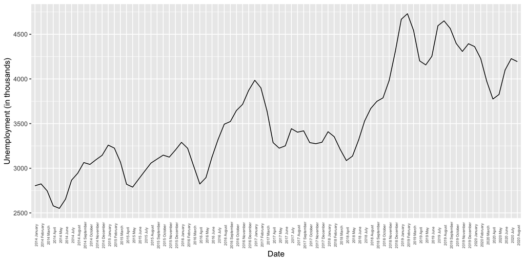

```r
occ_group_overall_m <- occ_group_overall %>%
  filter(month != "Annual") %>%
  mutate(year = factor(year),
         month = factor(month, levels = c("January","February", "March", "April", "May", "June", "July", "August", "September", "October", "November", "December")))


occ_group_male_m <- occ_group_male %>%
  filter(month != "Annual") %>%
  mutate(year = factor(year),
         month = factor(month, levels = c("January","February", "March", "April", "May", "June", "July", "August", "September", "October", "November", "December")))


occ_group_female_m <- occ_group_female %>%
  filter(month != "Annual") %>%
  mutate(year = factor(year),
         month = factor(month, levels = c("January","February", "March", "April", "May", "June", "July", "August", "September", "October", "November", "December")))

occ_group_overall_m <- occ_group_overall_m %>%
  mutate(date = factor(paste(year, month), levels = paste(year, month)))

ggplot(occ_group_overall_m, aes(date, total_unemployed)) +
  geom_line(aes(group = 1)) +
  labs(
    x = "Date",
    y = "Unemployment (in thousands)") +
  theme(axis.ticks.x = element_blank(),
        axis.text.x = element_text(angle = 90, size = 5))
```

#### Unemployment by Gender

Both genders have similar upward trend over time. However, males have higher unemployment than females. We’ll be covering this difference in the next graphs in details.

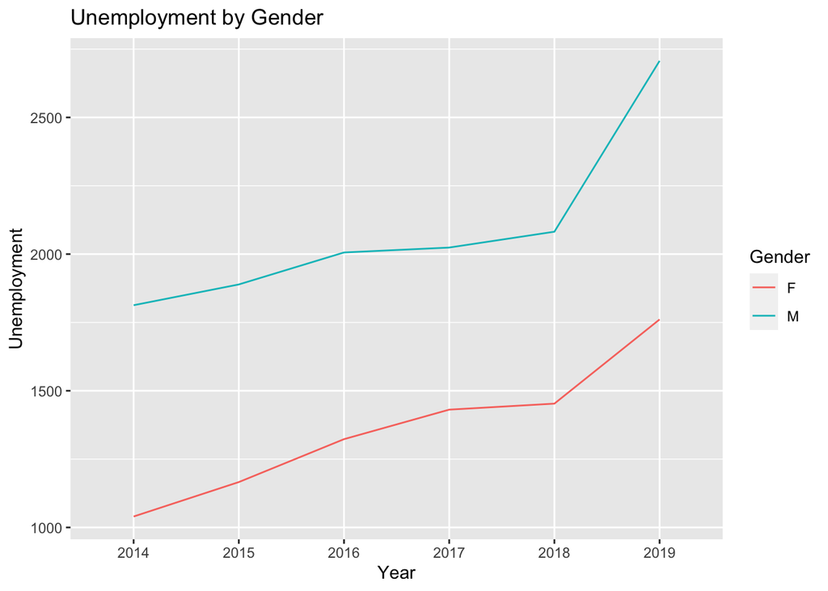

```r
occ_group_male_y <- occ_group_male %>%
  filter(month == "Annual") %>%
  mutate(year = factor(year))


year_male_x <- rep(unique(occ_group_male_y$year), times = (ncol(occ_group_male_y)-3))

group_male_y <- rep(colnames(occ_group_male_y[-c(1,2,3)]),
                 each = length(unique(year_male_x)))

values_male_z <- array(unlist(occ_group_male_y[1:6,4:12]))

gender_male_q <- rep("M", length(year_male_x))

og_male_df <- data.frame(year_male_x, group_male_y, values_male_z, gender_male_q)

occ_group_female_y <- occ_group_female %>%
  filter(month == "Annual") %>%
  mutate(year = factor(year))


year_female_x <- rep(unique(occ_group_female_y$year), times = (ncol(occ_group_female_y)-3))

group_female_y <- rep(colnames(occ_group_female_y[-c(1,2,3)]),
                 each = length(unique(year_female_x)))

values_female_z <- array(unlist(occ_group_female_y[1:6,4:12]))

gender_female_q <- rep("F", length(year_female_x))

og_female_df <- data.frame(year_female_x, group_female_y, values_female_z, gender_female_q)

colnames(og_male_df) <- c("year", "group", "values", "gender")
colnames(og_female_df) <- c("year", "group", "values", "gender")

total_og_df <- rbind(og_male_df, og_female_df)

total_og_df2 <- total_og_df %>%
  group_by(gender, year) %>%
  summarize(total = sum(values))

ggplot(total_og_df2, aes(x = year ,y = total, group = gender, color = gender)) +
  geom_line() +
  labs(x = "Year",
         y = "Unemployment",
         title = "Unemployment by Gender",
         color = "Gender")
```

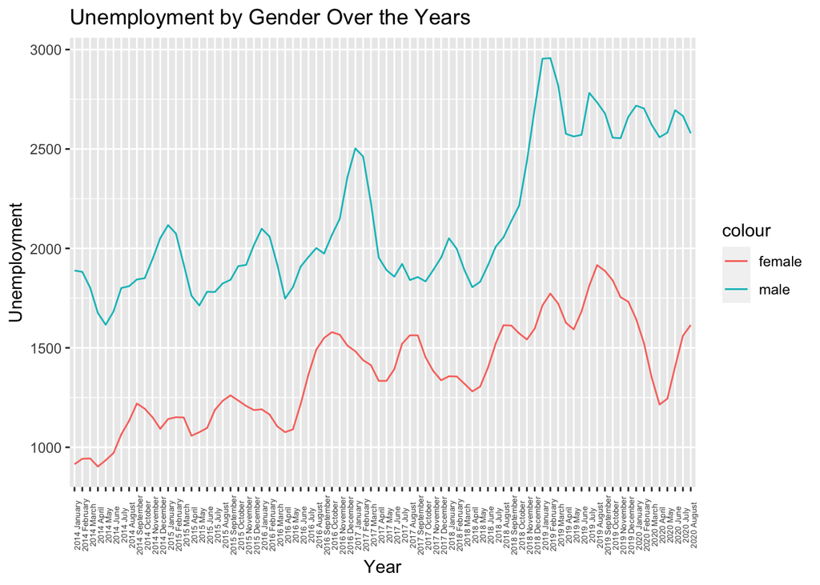

```r
job_search_female$month <- str_split_fixed(job_search_female$month, " - ", 2)[,2]
job_search_male$month <- str_split_fixed(job_search_male$month, " - ", 2)[,2]

monthly_jobsearch_male <- filter(job_search_male, !grepl("Annual", month))
monthly_jobsearch_female <- filter(job_search_female, !grepl("Annual", month))

unemp_gr_male<-monthly_jobsearch_male%>%
  transmute(month_year = paste(year, month, sep = " "), total_unemployed)

unemp_gr_female<-monthly_jobsearch_female%>%
  transmute(month_year = paste(year, month, sep = " "), total_unemployed)


unemp_merged <-merge(unemp_gr_female,unemp_gr_male, by="month_year", all=TRUE, sort = FALSE)

unemp_merged <- unemp_merged %>%
  rename(female=total_unemployed.x, male=total_unemployed.y)

#Grafikte x ekseni alfabetik sıraya göre değil, tarih sırasına göre gelmesi için yapılan dönüşüm
unemp_merged$month_year <- as.character(unemp_merged$month_year)
unemp_merged$month_year <- factor(unemp_merged$month_year, level=unemp_merged$month_year)

#Yıllara göre toplam işsizliğin cinsiyete göre dağılımı
ggplot(unemp_merged, aes(x=factor(month_year))) +
  geom_line(aes(y=female, color="female", group=1))+
  geom_line(aes(y=male, color="male", group=1))+
  theme(axis.text.x = element_text(angle=90, size=5))+
  labs(title = "Unemployment by Gender Over the Years",
       x="Year",
       y="Unemployment")
```

#### Seasonality Effect on Unemployment

There are two peaks in a year on average: Winter and Summer. Besides the seasonal jobs, graduation might also be the contributor to these peaks.

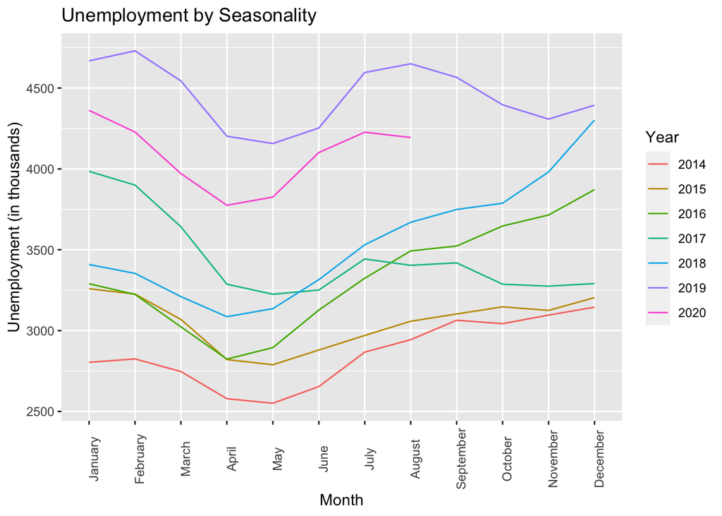

```r
ggplot(occ_group_overall_m, aes(factor(month), total_unemployed, group=year, color=year)) +
  geom_line() +
  labs(
    x = "Month",
    y = "Unemployment (in thousands)",
    title = "Unemployment by Seasonality",
    color = "Year") +
  theme(axis.text.x = element_text(angle = 90))
```

#### Unemployment by Occupational Group

From 2014 to 2019, total unemployment has increased by %57. Occupational groups with the highest growth are professionals (%108), elementary occupations (%64) and technicians and associate professionals (%55) ; whereas skilled agricultural, forestry and fishery workers (%0), managers (%20) and clerical support workers (%26) are the ones with the lowest growth. The graph below displays the distribution of unemployment by occupational group from 2014 to 2019. The highest proportion of unemployment in 2019 belongs to service and sales workers (%24 of all unemployment), followed by elementary occupations (%19) and craft and related trades workers (%14).

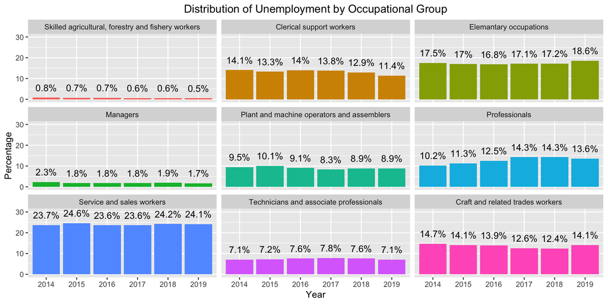

```r
occ_group_overall_y <- occ_group_overall %>%
  filter(month == "Annual") %>%
  mutate(year = factor(year))


year_x <- rep(unique(occ_group_overall_y$year), times = (ncol(occ_group_overall_y)-3))

group_y <- rep(colnames(occ_group_overall_y[-c(1,2,3)]),
                 each = length(unique(year_x)))

values_z <- array(unlist(occ_group_overall_y[1:6,4:12]))

og_df <- data.frame(year_x, group_y, values_z)

og_df_rate <- og_df %>%
  group_by(year_x) %>%
  mutate(Percentage = round(values_z/sum(values_z) * 100, 1))


og_df_rate$group_y <- as.factor(og_df_rate$group_y)
levels(og_df_rate$group_y) <- c("Skilled agricultural, forestry and fishery workers", "Clerical support workers", "Elemantary occupations", "Managers", "Plant and machine operators and assemblers", "Professionals", "Service and sales workers", "Technicians and associate professionals", "Craft and related trades workers")
ggplot(og_df_rate, aes(x = year_x, y = Percentage)) +
  geom_bar(stat = "identity", aes(fill = as.factor(group_y))) +
  geom_text(aes(label = paste0(Percentage, "%"), vjust = -1)) +
  facet_wrap(~group_y) +
  ggtitle("Distribution of Unemployment by Occupational Group") +
  theme(legend.position = "none",  plot.title = element_text(hjust = 0.5)) +
  xlab(label = "Year") +
  scale_y_continuous(limits = c(0,30))
```

#### Unemployment by Occupatipational Group and Gender

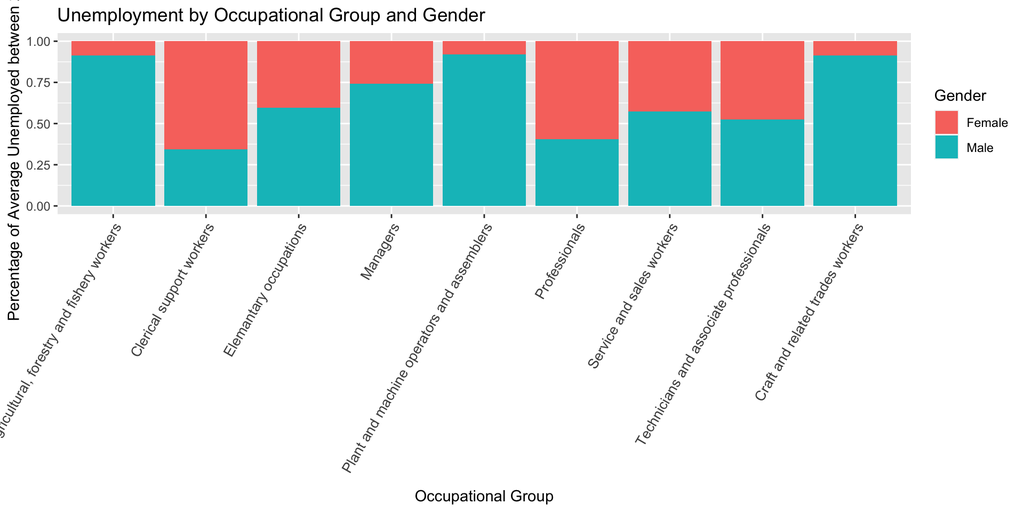

```r
total_og_df4 <- total_og_df %>%
  group_by(group, gender) %>%
  summarize(average_p_year = mean(values))

total_og_df4$gender <- as.factor(total_og_df4$gender)
levels(total_og_df4$gender) <- c("Female", "Male")

total_og_df4$group <- as.factor(total_og_df4$group)
levels(total_og_df4$group) <- c("Skilled agricultural, forestry and fishery workers", "Clerical support workers", "Elemantary occupations", "Managers", "Plant and machine operators and assemblers", "Professionals", "Service and sales workers", "Technicians and associate professionals", "Craft and related trades workers")

ggplot(total_og_df4, aes(group, average_p_year, fill = gender)) +
  geom_col(position = "fill") +
  labs(x = "Occupational Group",
       y = "Percentage of Average Unemployed between 2014-2019",
       title = "Unemployment by Occupational Group and Gender",
       fill = "Gender") +
  theme(axis.text.x = element_text(angle = 60, size = 10, vjust = 1, hjust = 1))
```

### Labour Force Status of Higher Education Graduates by Their Major

```r
deneme_major <- last_graduated_major %>%
  gather(key = "major", value = "value", -year, -statistics)

deneme_major_issizoran <- filter(deneme_major, grepl("İşsizlik oranı", statistics))

major_issizoran_wide <- spread(deneme_major_issizoran, year, value) %>%
  subset(select = -c(statistics))

major_issizoran_wide$trend <- round(((major_issizoran_wide$`2019`/major_issizoran_wide$`2014`)-1)*100,1)

major_issizoran_wide$major <- as.factor(major_issizoran_wide$major)
levels(major_issizoran_wide$major) <- c("Agriculture, forestry and fishery","Architecture and construction", "Arts", "Biology, environ-ment and related sciences", "Business and administration", "Education", "Engineering and engineering trades", "Health", "Higher education graduate", "Humanities", "Information and communi-cation technologies", "Journalism and information", "Languages", "Law", "Manufacturing and processing", "Mathematics and statistics", "Occupational health and transport services", "Personal services", "Physical science", "Security services", "Social and behavioural sciences", "Veterinary", "Welfare (Social services)")


major_top5 <- major_issizoran_wide %>%
  top_n(5, trend)

major_last5 <- major_issizoran_wide %>%
  arrange(trend) %>%
  head(5)

major_top5
```

```
## # A tibble: 5 x 8
##   major             `2014` `2015` `2016` `2017` `2018` `2019` trend
##   <fct>              <dbl>  <dbl>  <dbl>  <dbl>  <dbl>  <dbl> <dbl>
## 1 Health              3.14   5.01   6.34    9.6    9.6   11.4 263.
## 2 Humanities          6.71   9.04  10.5    13.2   13.2   15.8 136.
## 3 Languages           8.11  10.7   13.8    16.4   14.9   14.7  81.3
## 4 Security services   2.52   3.28   4.65    5      6.3    5.8 130.
## 5 Veterinary          6.67   8.16   7.27   10.7    8.9   11.2  68
```

```r
major_last5
```

```
## # A tibble: 5 x 8
##   major                          `2014` `2015` `2016` `2017` `2018` `2019` trend
##   <fct>                           <dbl>  <dbl>  <dbl>  <dbl>  <dbl>  <dbl> <dbl>
## 1 Journalism and information       29.2   17.4   19.2   19.1   23.8   21.8 -25.3
## 2 Personal services                12.9   15.4   16.7   14.3   12.2   11   -15.1
## 3 Biology, environ-ment and rel…   14.7   20.2   14.1   16     16.9   14.5  -1.1
## 4 Information and communi-catio…   16.8   17.1   17.0   19.9   14     16.7  -0.6
## 5 Business and administration      13.6   13.3   13.8   13.2   13.3   14.3   4.8
```

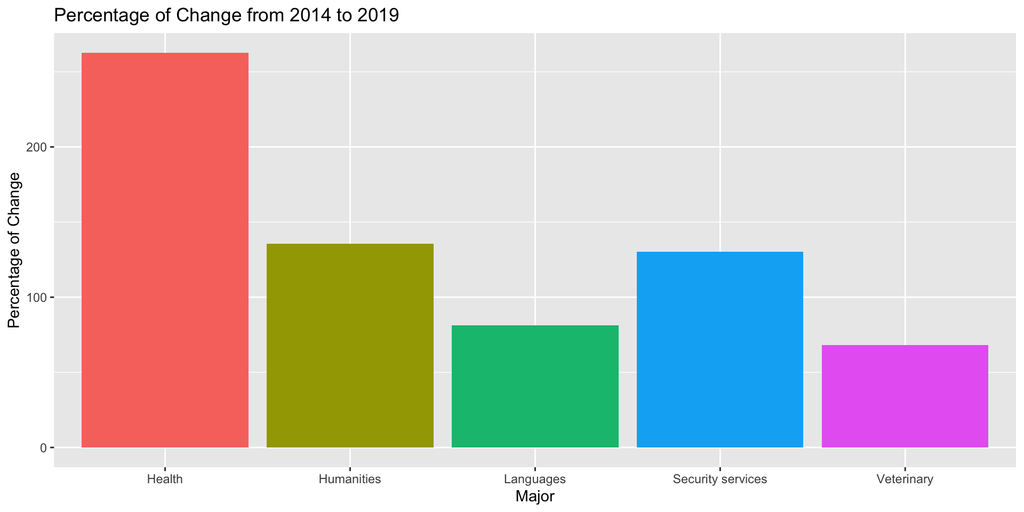

```r
ggplot(major_top5, aes(factor(major, levels = major), trend, fill = major)) +
  geom_col(position = "dodge") +
  theme(legend.position = "none")  +
  guides(fill=guide_legend(title="Major")) +
  labs(x = "Major",
       y = "Percentage of Change",
       title = "Percentage of Change from 2014 to 2019")
```

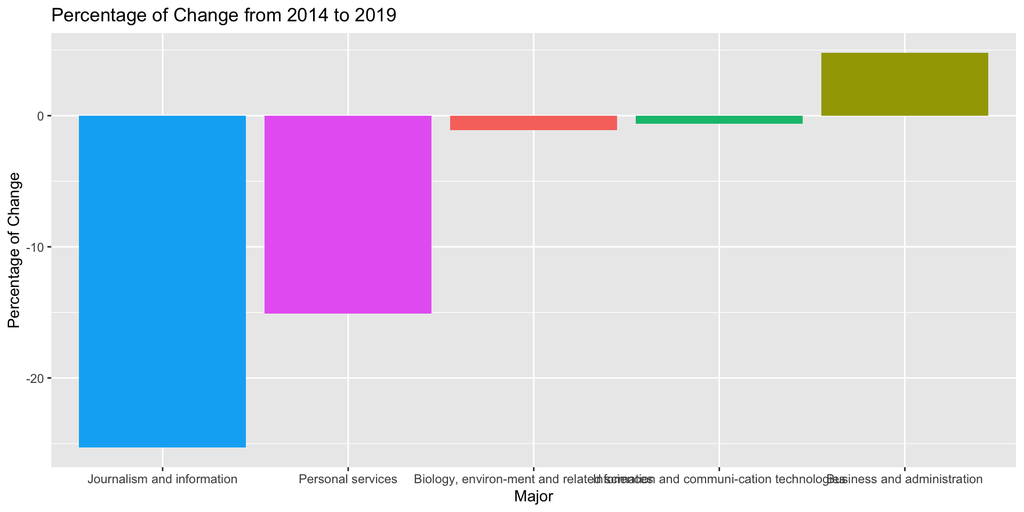

```r
ggplot(major_last5, aes(factor(major, levels = major), trend, fill = major)) +
  geom_col(position = "dodge") +
  theme(legend.position = "none")  +
  guides(fill=guide_legend(title="Major")) +
  labs(x = "Major",
       y = "Percentage of Change",
       title = "Percentage of Change from 2014 to 2019")
```

### Unemployed Job Searching People by the Channel

Establish Own Business: Represents people who are applying for loans, doing research or looking for a place to start a business. Turkish Employment Office: Represents people who have contacted or waited a call from Turkish Employment Office Newspaper: Represents people who are looking for a job on newspaper or put an advertisement on the newspaper to find a job Friends and Relatives: Asking friends and relatives for a job Employment Agencies: Represents people who have contacted with private employment agencies Direct Application to Employers: People who applied for jobs directly to companies Other: Job searching methods that cannot be categorized

In these six charts, different job searching methods were analyzed between the years 2014 and 2019. The percentage change in direct job applications, asking for a job to relatives and applications by newspapers were decreasing last six years. The decline in direct application may be because of fall in new job oppurtunities in companies in these period. Moreover, It is observed that the rate of job search with newspapers has decreased due to the shift to online channels. On the other hand, It is clearly seen that jop applications by Employment Agencies and Turkish Employment Office has increased last six years. The main explanation for this increase among methods can be summarized by those who cannot find a job by their own effort, apply for a job through ISKUR or other private employment agencies. Among these six job searching methods, the biggest percentage change can be seen in application through Turkish Employment Office (ISKUR) where percentage was 14.2% in 2014 and rose 24.3% in 2019.

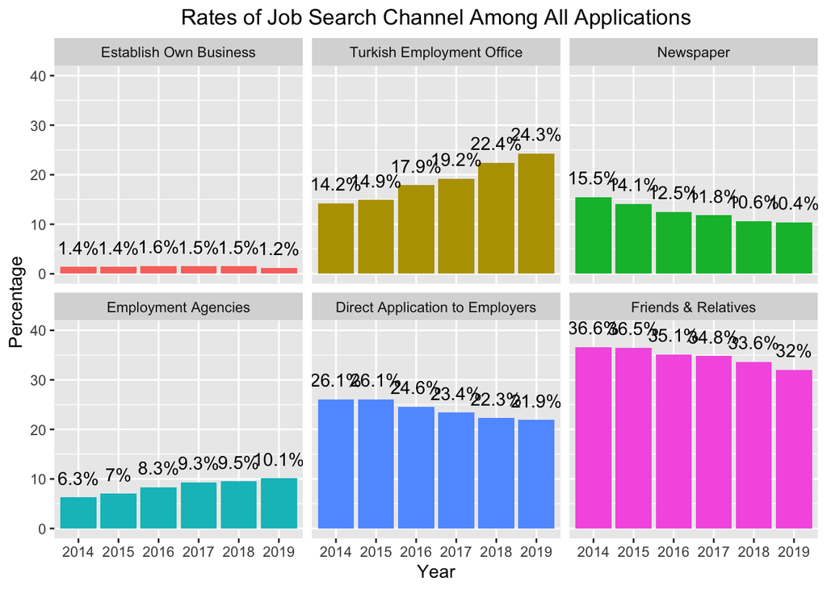

```r
job_search_overall_c <- job_search_overall %>%
  mutate(month = gsub("^.*?- ", "", month)) %>%
  filter(month == "Annual") %>%
  mutate(year = factor(year),
         establish_own_bus = look_place_equip_to_est_bus + look_credit_license_to_est_bus,
         newspaper = to_newspaper + insert_ad_to_newspaper,
         iskur = to_emp_office + wait_call_from_emp_office,
         waiting_result = wait_result_of_app + wait_result_of_comp_for_public_sec) %>%
  select(year, establish_own_bus, newspaper, iskur, to_emp_agencies, to_employers, to_relatives)

Year <- rep(unique(job_search_overall_c$year), times = (ncol(job_search_overall_c)-1))

Channel <- rep(colnames(job_search_overall_c[-c(1,1)]),
               each = length(unique(Year)))

Count <- array(unlist(job_search_overall_c[1:6,2:7]))

js_df <- data.frame(Year, Channel, Count)

js_df_rate <- js_df %>%
  group_by(Year) %>%
  mutate(Percentage = round(Count/sum(Count) * 100, 1))

js_df_rate$Channel <- as.factor(js_df_rate$Channel)

levels(js_df_rate$Channel) <- c("Establish Own Business", "Turkish Employment Office", "Newspaper",
                                "Employment Agencies", "Direct Application to Employers", "Friends & Relatives")

ggplot(js_df_rate, aes(x = Year, y = Percentage)) +
  geom_bar(stat = "identity", aes(fill = as.factor(Channel))) +
  geom_text(aes(label = paste0(Percentage, "%"), vjust = -1)) +
  facet_wrap(~Channel) +
  ggtitle("Rates of Job Search Channel Among All Applications") +
  theme(legend.position = "none",  plot.title = element_text(hjust = 0.5)) +
  scale_y_continuous(limits = c(0,40))
```

```r
annual_jobsearch <- filter(job_search_overall, grepl("Annual", month))

annual_jobsearch_melt <- annual_jobsearch %>%
  select(year, month, total_unemployed, to_employers, to_relatives, to_emp_office, to_emp_agencies, to_newspaper, insert_ad_to_newspaper, take_interview, look_place_equip_to_est_bus, look_credit_license_to_est_bus, wait_call_from_emp_office, wait_result_of_app, wait_result_of_comp_for_public_sec, others)%>%
  gather(key="type", value = "value", -month, -year)
```

```r
job_search_overall$month <- str_split_fixed(job_search_overall$month, " - ", 2)[,2]
job_search_overall
```

```
## # A tibble: 86 x 16
##     year month total_unemployed to_employers to_relatives to_emp_office
##    <dbl> <chr>            <dbl>        <dbl>        <dbl>         <dbl>
##  1  2014 Janu…             2804         1826         2581           592
##  2  2014 Febr…             2825         1814         2605           573
##  3  2014 March             2747         1731         2535           531
##  4  2014 April             2579         1621         2364           489
##  5  2014 May               2551         1603         2326           500
##  6  2014 June              2654         1689         2417           507
##  7  2014 July              2867         1810         2601           555
##  8  2014 Augu…             2944         1880         2652           578
##  9  2014 Sept…             3064         2005         2767           626
## 10  2014 Octo…             3043         2057         2779           642
## # … with 76 more rows, and 10 more variables: to_emp_agencies <dbl>,
## #   to_newspaper <dbl>, insert_ad_to_newspaper <dbl>, take_interview <dbl>,
## #   look_place_equip_to_est_bus <dbl>, look_credit_license_to_est_bus <dbl>,
## #   wait_call_from_emp_office <dbl>, wait_result_of_app <dbl>,
## #   wait_result_of_comp_for_public_sec <dbl>, others <dbl>
```

```r
monthly_jobsearch <- filter(job_search_overall, !grepl("Annual", month))

monthly_jobsearch
```

```
## # A tibble: 80 x 16
##     year month total_unemployed to_employers to_relatives to_emp_office
##    <dbl> <chr>            <dbl>        <dbl>        <dbl>         <dbl>
##  1  2014 Janu…             2804         1826         2581           592
##  2  2014 Febr…             2825         1814         2605           573
##  3  2014 March             2747         1731         2535           531
##  4  2014 April             2579         1621         2364           489
##  5  2014 May               2551         1603         2326           500
##  6  2014 June              2654         1689         2417           507
##  7  2014 July              2867         1810         2601           555
##  8  2014 Augu…             2944         1880         2652           578
##  9  2014 Sept…             3064         2005         2767           626
## 10  2014 Octo…             3043         2057         2779           642
## # … with 70 more rows, and 10 more variables: to_emp_agencies <dbl>,
## #   to_newspaper <dbl>, insert_ad_to_newspaper <dbl>, take_interview <dbl>,
## #   look_place_equip_to_est_bus <dbl>, look_credit_license_to_est_bus <dbl>,
## #   wait_call_from_emp_office <dbl>, wait_result_of_app <dbl>,
## #   wait_result_of_comp_for_public_sec <dbl>, others <dbl>
```

```r
unemp_gr<-monthly_jobsearch%>%
  transmute(month_year = paste(year, month, sep = " "), total_unemployed)

#Grafikte x ekseni alfabetik sıraya göre değil, tarih sırasına göre gelmesi için yapılan dönüşüm
#unemp_gr$month_year <- as.character(unemp_gr$month_year)
#unemp_gr$month_year <- factor(unemp_gr$month_year, level=unemp_gr$month_year)
```

### İŞKUR ile özel istihdam bürolarının yıllara göre durumları

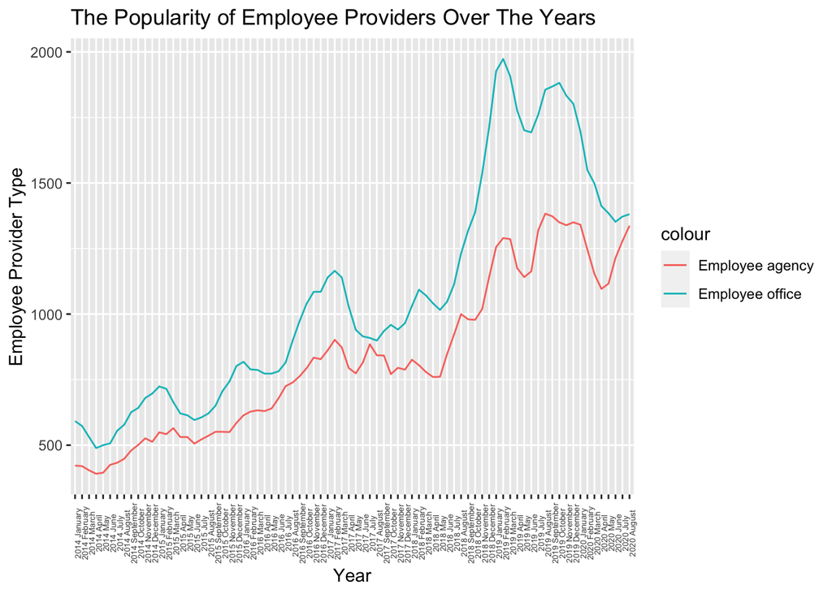

```r
applied_office_types<- monthly_jobsearch %>%
  transmute(month_year = paste(year, month, sep = " "), to_emp_office, to_emp_agencies)

applied_office_types_melted <- applied_office_types %>%
  melt(id.vars="month_year", variable.name= "Office_Type", value.name="Value")


#Grafikte x ekseni alfabetik sıraya göre değil, tarih sırasına göre gelmesi için yapılan dönüşüm
applied_office_types$month_year <- as.character(applied_office_types$month_year)
applied_office_types$month_year <- factor(applied_office_types$month_year, level=applied_office_types$month_year)

#İş arama kurumlarından devlet ve özel kurumların yıllara göre popülaritesi
ggplot(applied_office_types, aes(x=factor(month_year))) +
  geom_line(aes(y=to_emp_office, color="Employee office", group=1))+
  geom_line(aes(y=to_emp_agencies, color="Employee agency", group=1))+
  theme(axis.text.x = element_text(angle =90, size=5))+
  labs(title="The Popularity of Employee Providers Over The Years",
       x="Year",
       y="Employee Provider Type")
```

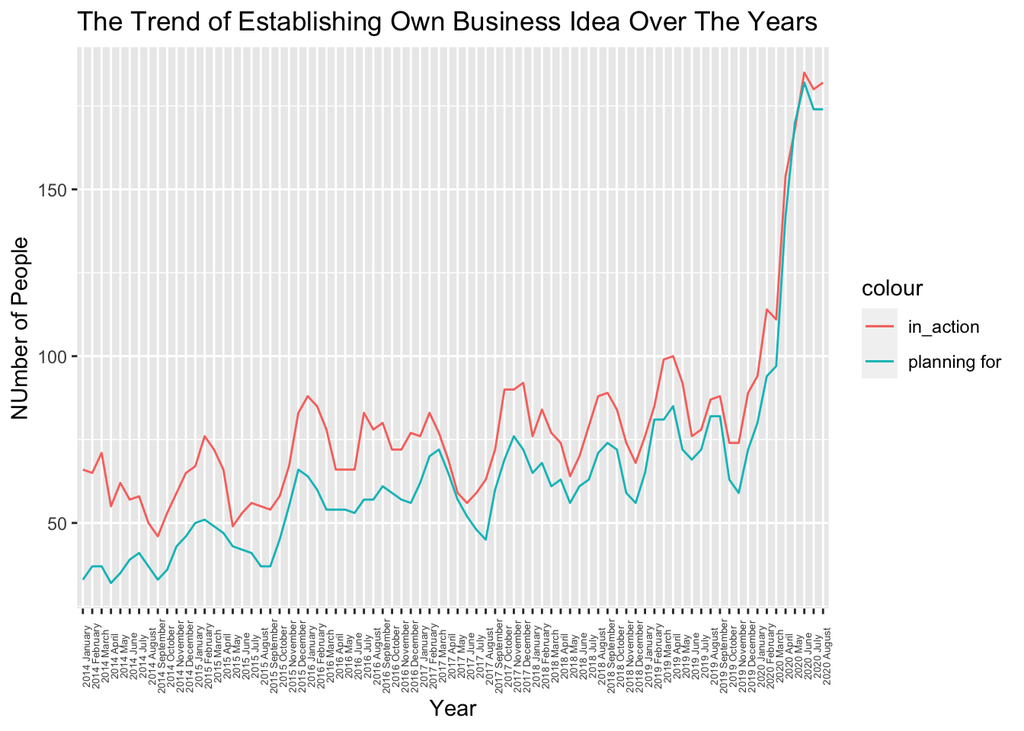

```r
#Kendi iş yerini kurmayı planlayanlar ve kurmak için aksiyona geçenlerin durumu
own_bus_df <- monthly_jobsearch %>%
  transmute(month_year = paste(year, month, sep = " "), look_place_equip_to_est_bus, look_credit_license_to_est_bus) %>%
  rename(in_action=look_place_equip_to_est_bus, planning_for = look_credit_license_to_est_bus)


#Grafikte x ekseni alfabetik sıraya göre değil, tarih sırasına göre gelmesi için yapılan dönüşüm
own_bus_df$month_year <- as.character(own_bus_df$month_year)
own_bus_df$month_year <- factor(own_bus_df$month_year, level=own_bus_df$month_year)


ggplot(own_bus_df, aes(x=factor(month_year))) +
  geom_line(aes(y=in_action, color="in_action", group=1))+
  geom_line(aes(y=planning_for, color="planning for", group=1))+
  theme(axis.text.x = element_text(angle =90, size=5))+
  labs(title="The Trend of Establishing Own Business Idea Over The Years",
       x="Year",
       y="NUmber of People")
```

### Employed & Unemployed by Educational Level

```r
educational_level_overall$month <- str_split_fixed(educational_level_overall$month, " - ", 2)[,2]

#Excel'de 2014 Ocak ayı yazılımında " - " yerine "- " şeklinde olduğu için January manuel eklendi
educational_level_overall$month[1]<-"January"


monthly_educational <- filter(educational_level_overall, !grepl("Annual", month))

total_labour_month<-monthly_educational%>%
  transmute(month_year = paste(year, month, sep = " "), illterate=lf_illeterate, less_than_hs=lf_less_than_hs, highschool=lf_highschool, voc_hs=lf_voc_hs, higher_ed=lf_higher_ed)
```

```r
yearly_educational <- filter(educational_level_overall, grepl("Annual", month))
total_labour_yearly_educational <- yearly_educational%>%
  transmute(year=as.character(year),illeterate=lf_illeterate, less_than_hs=lf_less_than_hs, highschool=lf_highschool, voc_hs=lf_voc_hs, higher_ed=lf_higher_ed)

total_labour_yearly_educational_melt <- total_labour_yearly_educational %>%
  gather(key="type", value="value", -year)
```

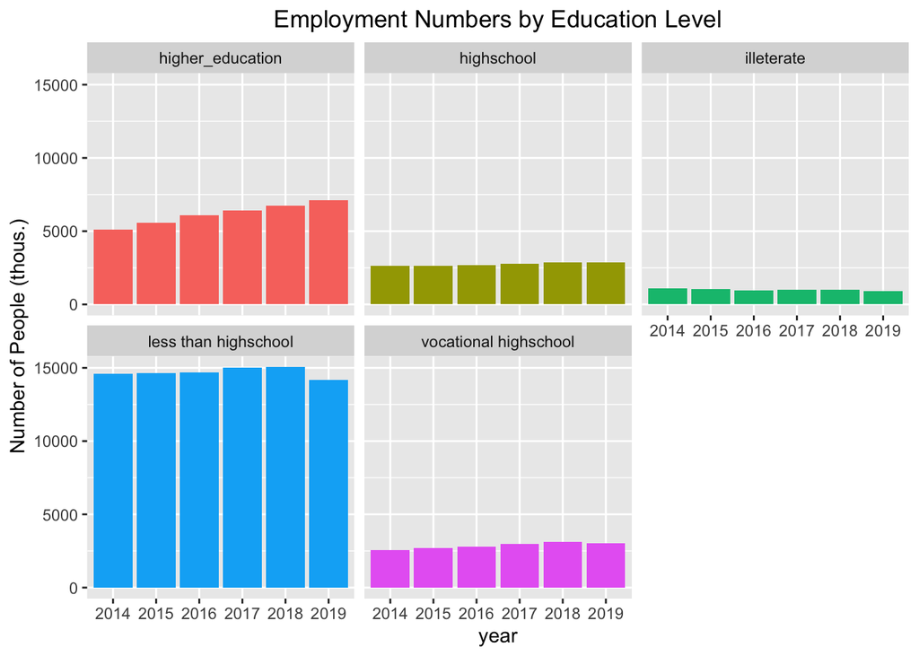

```r
emp_yearly_educational <- yearly_educational %>%
  transmute(year=as.character(year), illeterate=emp_illeterate, less_than_hs=emp_less_than_hs, highschool=emp_highschool, voc_hs=emp_voc_hs, higher_ed=emp_higher_ed)

emp_yearly_educational_melt<-emp_yearly_educational %>%
  gather(key="Education_Level", value="Person", -year )

# ggplot(emp_yearly_educational_melt, aes(x=year, y=Person, fill=factor(Education_Level, levels= c("higher_ed", "voc_hs", "highschool", "less_than_hs", "illeterate"))))+
#   geom_bar(position = "stack")+
#   guides(fill=guide_legend(title="Education Types"))+
#   labs(title = "Number of Employed People by Education Levels Over the Years",
#        y="Employed People")

emp_yearly_educational_melt$Education_Level <- as.factor(emp_yearly_educational_melt$Education_Level)
levels(emp_yearly_educational_melt$Education_Level) <- c("higher_education", "highschool", "illeterate", "less than highschool", "vocational highschool")


ggplot(emp_yearly_educational_melt, aes(x = year, y = Person)) +
  geom_bar(stat = "identity", aes(fill = as.factor(Education_Level))) +
  facet_wrap(~ Education_Level)+
  labs(title="Employment Numbers by Education Level",
       y="Number of People (thous.)")+
  theme(legend.position = "none",  plot.title = element_text(hjust = 0.5))
```

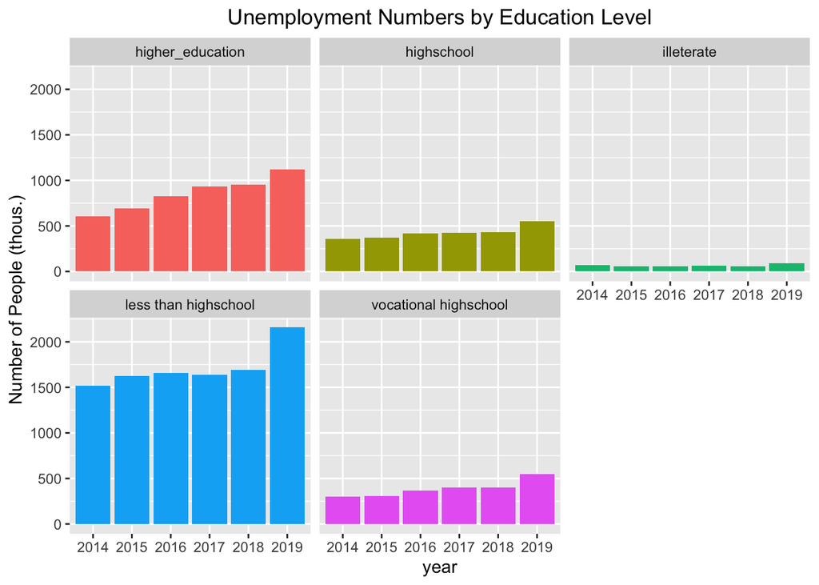

```r
unemp_yearly_educational <- yearly_educational %>%
  transmute(year=as.character(year), illeterate=unemp_illeterate, less_than_hs=unemp_less_than_hs, highschool=unemp_highschool, voc_hs=unemp_voc_hs, higher_ed=unemp_higher_ed)

unemp_yearly_educational_melt<-unemp_yearly_educational %>%
  gather(key="Education_Level", value="Person", -year )

unemp_yearly_educational_melt$Education_Level <- as.factor(unemp_yearly_educational_melt$Education_Level)
levels(unemp_yearly_educational_melt$Education_Level) <- c("higher_education", "highschool", "illeterate", "less than highschool", "vocational highschool")

ggplot(unemp_yearly_educational_melt, aes(x = year, y = Person)) +
  geom_bar(stat = "identity", aes(fill = as.factor(Education_Level))) +
  facet_wrap(~ Education_Level)+
  labs(title="Unemployment Numbers by Education Level",
       y="Number of People (thous.)")+
  theme(legend.position = "none",  plot.title = element_text(hjust = 0.5))
```